# STAT2401 Analysis of Experiments

Practical 7: Solution

## Learning Check

When you complete this session, you will be able to:

1. understand the matrix representation of Simple Linear Regression (SLR);
2. understand the Multiple Linear Regression (MLR) and its matrix representation;
3. understand Multiple Linear Regression modelling using R including interpretations;
4. understand parameter estimation and hypothesis testing for the MLR;
5. perform exploratory data analysis for MLR before modelling.

```r
knitr::opts_chunk$set(prompt=FALSE, comment=NA, tidy=TRUE, error=TRUE, warning=FALSE, message=FALSE)
```

## Question 1 SLR in a matrix form

The data below show the number of competing loan companies operating in the city (X) and the number of loans (per thousand) made in that city that are currently delinquent (Y):

```r
X=c(4,    1,      2,      3,      3,       4)
Y=c(16, 5,   10,      15,   13, 22)
```

In the lecture we showed that
$$\hat{\beta}= (X^{T}X)^{-1} X^{T}Y$$

1. Formulate the matrices $X, Y$ and the SLR model equation based on the data.

```r
X=c(4,    1,      2,      3,      3,       4)
Y=c(16, 5,   10,      15,   13, 22)  ## vec Y
One=c(1,1,1,1,1,1)
Xmat=cbind(One,X)  ## matrix X
Xmat
Y
```

2. Calculate the matrices multiplications using R for $Y^{T}Y, X^{T}X.$

```r
YtY=t(Y)%*%Y  ## Y'Y matrix multiplication %*%
YtY
XXt=t(Xmat)%*%Xmat ## X'X 2x2 matrix
XtX
```

```r
invX=solve(XtX)
invX
check=(XtX)%*%invX
check  # identity 2x2
```

3. Calculate the estimates of $\beta_1$ using the above matrix formula in R.

```r
betahat=solve(XtX)%*%t(Xmat)%*%Y
betahat
```

The estimates are $\hat{\beta}_0=0.439;\hat{\beta}_1=4.610$

4. Find $\hat{\epsilon}^T,$ SSE and $\hat{\sigma}^2.$

```r
Yhat=Xmat%*%betahat  # Predicted
Yhat
Res=Y-Yhat  # Residuals
Res
SSE=t(Res)%*%Res  ## SSE Sum of Squares Error
SSE
n=6
s2=SSE/(n-2)  ## Estimate of sigma^2
s2   ## hat(sigma^2)
s=sqrt(s2) ## estimate of sigma
s
```

5. Compare the answers in (a)-(d) using *lm* function in R.

```r
check.lm=lm(Y~X)
summary(check.lm)
anova(check.lm)
```

## Question 2 Gasoline.csv

The dataset presents a set of data on the gasoline mileage performance of 32 different automobiles.

The data has the following variables

```
     - (1) y:  Miles/gallon;
     - (2) x1: Displacement (cubic in.);
     - (3) x2: Horsepower (ft-lb);
     - (4) x3: Torqne (ft-lb);
     - (5) x4: Compression ratio;
     - (6) x5: Rear axle ratio;
     - (7) x6: Carburetor (barrels);
     - (8) x7: No. of transmission speeds;
     - (9) x8: Overall length (in.);
     - (10) x9: Width (in.);
     - (11) x10: Weight (lb);
     - (12) x11: Type of transmission (1: automatic; 0: manual).
```

1. Fit a multiple linear regression model relating gasoline mileage (y) (miles per gallon) to engine displacement (x1) and the number of carburetor barrels (x6).

```r
Gasoline = read.csv("Gasoline.csv",header=TRUE)
```

Fit the regression model and present the output

```r
M2 = lm(y~x1+x6,data=Gasoline)
summary(M2)
```

```
Call:
lm(formula = y ~ x1 + x6, data = Gasoline)

Residuals:
    Min      1Q  Median      3Q     Max
-7.0623 -1.6687 -0.3628  1.6221  6.2305

Coefficients:
             Estimate Std. Error t value Pr(>|t|)
(Intercept) 32.884551   1.535408  21.417  < 2e-16 ***
x1          -0.053148   0.006137  -8.660 1.55e-09 ***
x6           0.959223   0.670277   1.431    0.163
---
Signif. codes:  0 ‘***’ 0.001 ‘**’ 0.01 ‘*’ 0.05 ‘.’ 0.1 ‘ ’ 1

Residual standard error: 3.013 on 29 degrees of freedom
Multiple R-squared:  0.7873,    Adjusted R-squared:  0.7726
F-statistic: 53.67 on 2 and 29 DF,  p-value: 1.79e-10
```

```r
M3 = lm(y~x1+x2+x3+x4+x5+x6+x7+x8+x9+x10+x11,data=Gasoline)
summary(M3)
```

```
Call:
lm(formula = y ~ x1 + x2 + x3 + x4 + x5 + x6 + x7 + x8 + x9 +
    x10 + x11, data = Gasoline)

Residuals:
    Min      1Q  Median      3Q     Max
-5.3441 -1.6711 -0.4486  1.4906  5.2508

Coefficients:
             Estimate Std. Error t value Pr(>|t|)
(Intercept) 17.339838  30.355375   0.571   0.5749
x1          -0.075588   0.056347  -1.341   0.1964
x2          -0.069163   0.087791  -0.788   0.4411
x3           0.115117   0.088113   1.306   0.2078
x4           1.494737   3.101464   0.482   0.6357
x5           5.843495   3.148438   1.856   0.0799 .
x6           0.317583   1.288967   0.246   0.8082
x7          -3.205390   3.109185  -1.031   0.3162
x8           0.180811   0.130301   1.388   0.1822
x9          -0.397945   0.323456  -1.230   0.2344
x10         -0.005115   0.005896  -0.868   0.3971
x11          0.638483   3.021680   0.211   0.8350
---
Signif. codes:  0 ‘***’ 0.001 ‘**’ 0.01 ‘*’ 0.05 ‘.’ 0.1 ‘ ’ 1

Residual standard error: 3.227 on 18 degrees of freedom
  (2 observations deleted due to missingness)
Multiple R-squared:  0.8355,    Adjusted R-squared:  0.7349
F-statistic:  8.31 on 11 and 18 DF,  p-value: 5.231e-05
```

Consider the model as
$$y = \beta_0 +
\beta_1 \texttt{x1} + \beta_2 \texttt{x6} + \epsilon$$

where $\epsilon$ is a normal random variable.

So the estimates are
$$\hat\beta_0
=32.884551 \quad \hat\beta_1 = -0.053148 \quad \hat\beta_2 =
0.959223$$
and the fitted line is
$$\widehat{\texttt{y}} = 32.884551
-0.053148\texttt{x1}
+0.959223 \texttt{x6}$$
(b) Test whether the model is statistically significant at the level 5%.

To test H$_0:\beta_1=\beta_2=0$ vs H$_1:$ Not H$_0$, we can look the $p$-value from the output. the $p$-value is 1.79e-10 $<0.05=\alpha$, so the model is statistically significant at the level 5%.

Construct the 6 steps for this question.

3. Test whether the variable x6 is statistically significant at the level 5% given the present of the variable x1.

To test H$_0:\beta_2=0$ vs H$_1:\beta_2\neq 0$, we can look the $p$-value from the output. the $p$-value is 0.163$>0.05=\alpha$, so the model is NOT statistically significant at the level 5%.

4. Determine a 95% CI for the regression coefficient of x1.

```r
confint(M2,level=0.95)
```

```
                  2.5 %      97.5 %
(Intercept) 29.74428901 36.02481266
x1          -0.06569892 -0.04059641
x6          -0.41164739  2.33009349
```

## Question 3 Adapted from Sheather (2009) Chapter 5: Menu pricing in a new Italian restaurant in New York City

The aim of this scenario is to produce a regression model to predict the price of dinner using data from surveys of customers of 168 Italian restaurants in the target area are available.

The data are in the form of the average of customer views on:

- Y = Price = the price (in $US) of dinner (including 1 drink & a tip)
- X1= Food = customer rating of the food (out of 30)
- X2= Décor = customer rating of the decor (out of 30)
- X3= Service = customer rating of the service (out of 30)
- X4= East = dummy variable = 1 (0) if the restaurant is east (west) of Fifth Avenue

The data are given on the book web site in the file *nyc.csv.*

1. Perform exploratory data analysis on the data using scatter plot matrix and boxplots.

```r
nyc=read.csv("nyc.csv")
head(nyc)
```

|  | Case | Restaurant | Price | Food | Decor | Service | East |
| --- | --- | --- | --- | --- | --- | --- | --- |
| 1 | 1 | Daniella Ristorante | 43 | 22 | 18 | 20 | 0 |
| 2 | 2 | Tello's Ristorante | 32 | 20 | 19 | 19 | 0 |
| 3 | 3 | Biricchino | 34 | 21 | 13 | 18 | 0 |
| 4 | 4 | Bottino | 41 | 20 | 20 | 17 | 0 |
| 5 | 5 | Da Umberto | 54 | 24 | 19 | 21 | 0 |
| 6 | 6 | Le Madri | 52 | 22 | 22 | 21 | 0 |

```r
nyc1=nyc[,c(-1,-2,-7)]  ## nyc1 consists of all numerical data
View(nyc1)
```

```r
nyc$East=factor(nyc$East)
head(nyc)
```

|  | Case | Restaurant | Price | Food | Decor | Service | East |
| --- | --- | --- | --- | --- | --- | --- | --- |
| 1 | 1 | Daniella Ristorante | 43 | 22 | 18 | 20 | 0 |
| 2 | 2 | Tello's Ristorante | 32 | 20 | 19 | 19 | 0 |
| 3 | 3 | Biricchino | 34 | 21 | 13 | 18 | 0 |
| 4 | 4 | Bottino | 41 | 20 | 20 | 17 | 0 |
| 5 | 5 | Da Umberto | 54 | 24 | 19 | 21 | 0 |
| 6 | 6 | Le Madri | 52 | 22 | 22 | 21 | 0 |

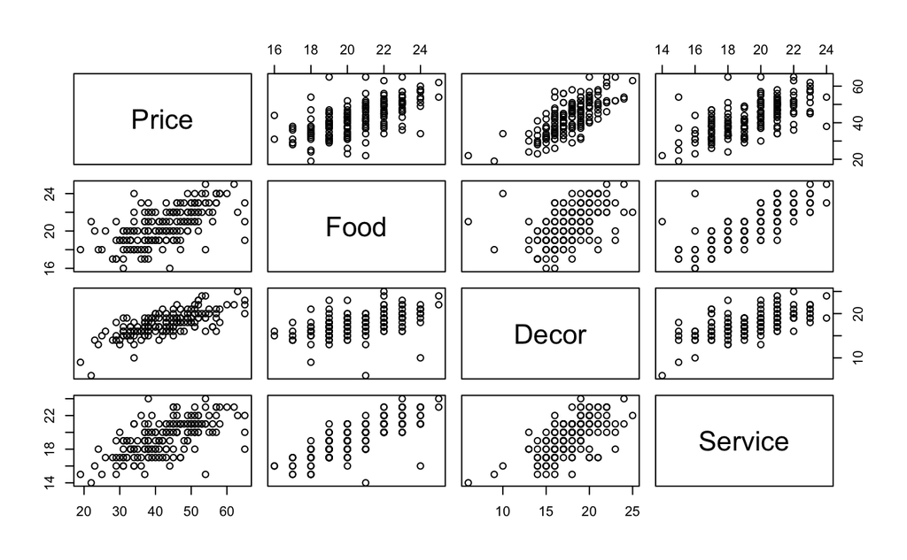

```r
# Scatterplot
pairs(nyc1)
library(PerformanceAnalytics)  ## install this
```

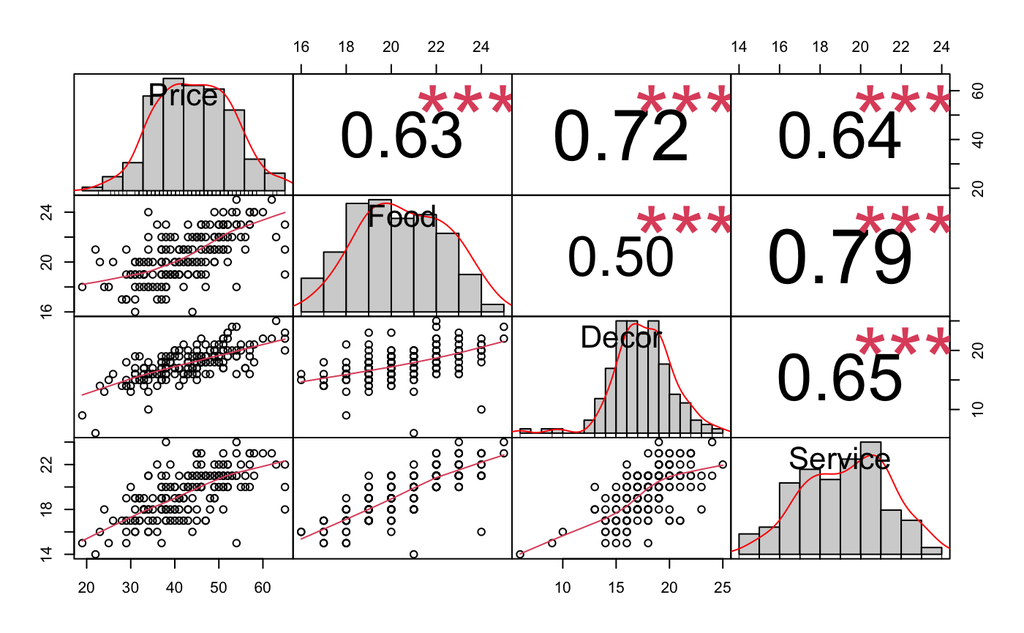

```r
chart.Correlation(nyc1)
```

Histograms: The variables Price and Food have symmetric shapes, Decor has a skewed to the left and Service has a bimodal shape.

```r
par(mfrow=c(2,2))
boxplot(Price~East, data=nyc, xlab="1=East, 0=West")
boxplot(Food~East, data=nyc)
```

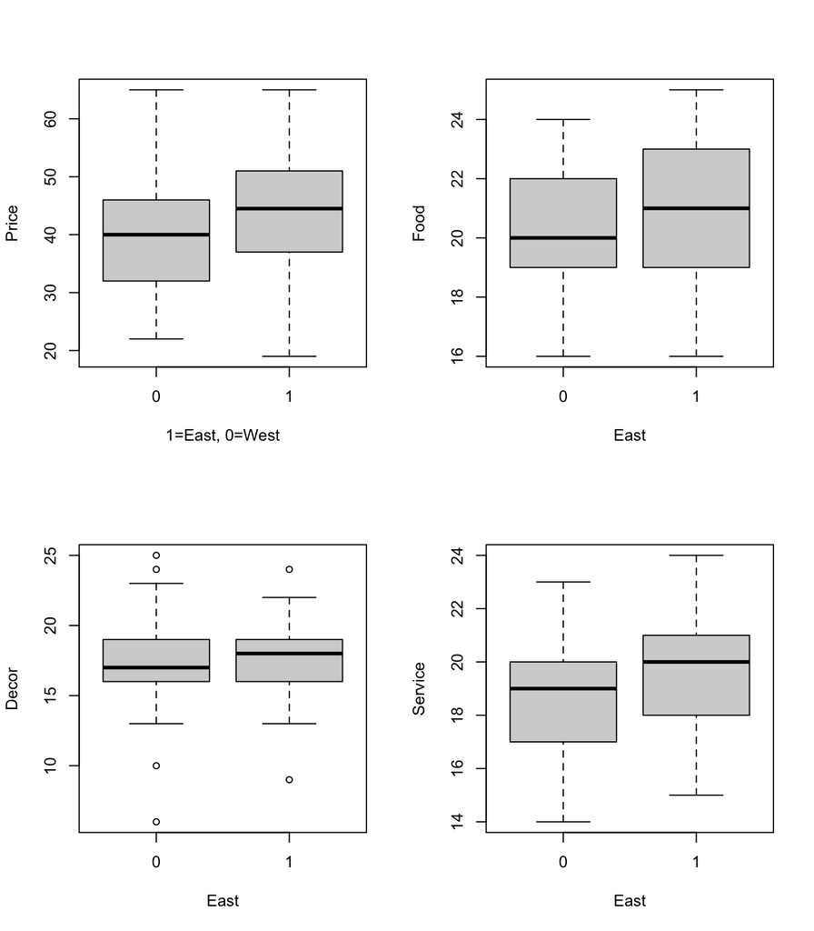

```r
boxplot(Decor~East, data=nyc)
boxplot(Service~East, data=nyc)
```

In all these side by side boxplots, restaurants in the East has higher Price, Food, Decor and Service in terms of the median ratings. The shapes distribution of East are symmetric with similar spreads to West.

This is how to display 3D plot (OPTIONAL). Interpret?

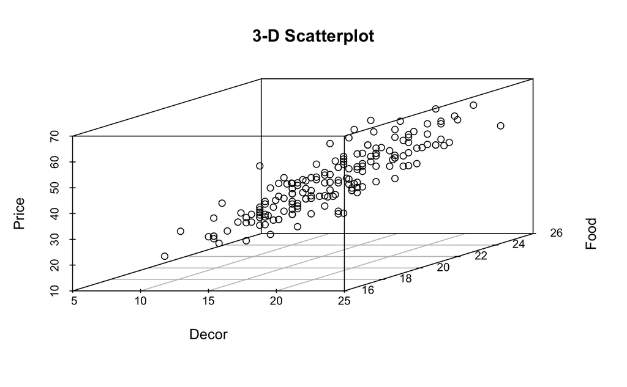

```r
library(scatterplot3d)
with(nyc, {
   scatterplot3d(x = Decor,
                 y = Food,
                 z = Price,
                 main="3-D Scatterplot")
})
```

An extension with colors and labels (OPTIONAL). The label is the case number. Interpret No 35, 88. Dont go to No 115 (low price, low ratings)

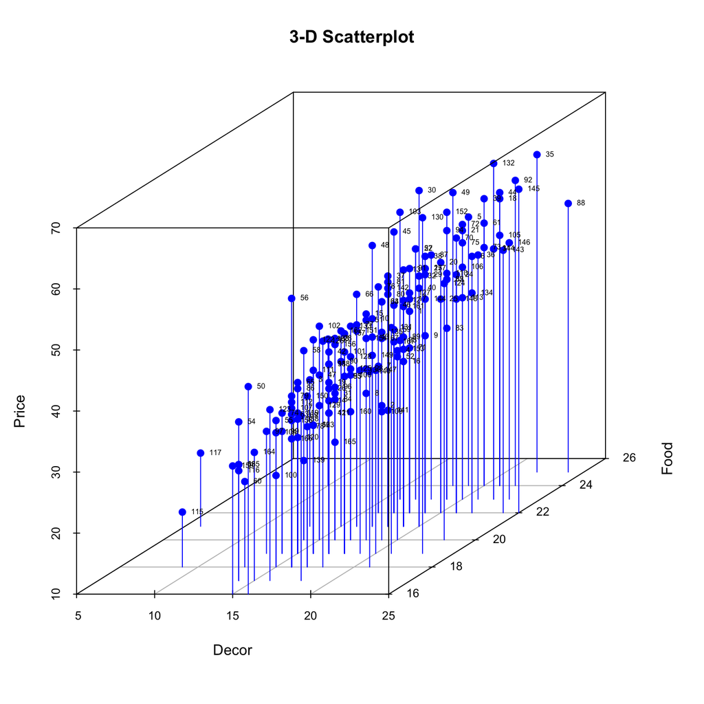

```r
library(scatterplot3d)
with(nyc, {
  s3d <- scatterplot3d(
    x = Decor,
    y = Food,
    z = Price,
    color = "blue",
    pch = 19,
    type = "h",
    main = "3-D Scatterplot",
    xlab = "Decor",
    ylab = "Food",
    zlab = "Price")

  # convert 3-D coords to 2D projection
  s3d.coords <- s3d$xyz.convert(Decor,Food,Price)

  # plot text with 50% shrink and place to right of points
  text(s3d.coords$x,
       s3d.coords$y,
       labels = row.names(nyc),
       cex = .5,
       pos = 4)
})
```

2. Develop a regression model that directly predicts the price of dinner (in dollars) using a subset or all of the 4 potential predictor variables listed above.

```r
ny.lm=lm(Price~Food+Decor+Service+East,data=nyc)
summary(ny.lm)
```

```
Call:
lm(formula = Price ~ Food + Decor + Service + East, data = nyc)

Residuals:
     Min       1Q   Median       3Q      Max
-14.0465  -3.8837   0.0373   3.3942  17.7491

Coefficients:
              Estimate Std. Error t value Pr(>|t|)
(Intercept) -24.023800   4.708359  -5.102 9.24e-07 ***
Food          1.538120   0.368951   4.169 4.96e-05 ***
Decor         1.910087   0.217005   8.802 1.87e-15 ***
Service      -0.002727   0.396232  -0.007   0.9945
East1         2.068050   0.946739   2.184   0.0304 *
---
Signif. codes:  0 ‘***’ 0.001 ‘**’ 0.01 ‘*’ 0.05 ‘.’ 0.1 ‘ ’ 1

Residual standard error: 5.738 on 163 degrees of freedom
Multiple R-squared:  0.6279,    Adjusted R-squared:  0.6187
F-statistic: 68.76 on 4 and 163 DF,  p-value: < 2.2e-16
```

The initial regression model is

*Price = – 24.02 + 1.54 Food + 1.91 Decor – 0.003 Service + 2.07 East*

At this point we shall leave the variable Service in the model even though its regression coefficient is not statistically significant.

3. Explain the fitted model, by interpreting the slopes and intercept.

```r
ny1.lm=lm(Price~Food+Decor+East,data=nyc)
summary(ny1.lm)
```

The final regression model is

*Price = – 24.03 + 1.54 Food + 1.91 Decor + 2.07 East*

The interpretations:

- $\hat{\beta}_0=-24.03$: Not interpretable.
- $\hat{\beta}_1=1.54$: Assuming Decor and East are constants, for every 1 unit increase in Food, Price increases by 1.54.
- $\hat{\beta}_2=1.91$: Assuming Food and East are constants, for every 1 unit increase in Decor, Price increases by 1.91.
- $\hat{\beta}_3=2.07$: Assuming Food and Decor are constants, when a restaurant in in the East, Price increases by 2.07.

4. Perform hypothesis testing about $H_0: \beta_j=0$ against $H_1: \beta_j \not=0$ for $j=0,1,...,3.$

The solution is provided for $\beta_1$. Please repeat the steps for other parameters.

*6 steps hypothesis testing for $\beta_1$:*

1. $H_0: \beta_1 = 0, H_1:\beta_1 \not=0$
2. The test statistic (from R output as in the above):

$t=\frac{\hat{\beta}_1-0}{se(\hat{\beta}_1)}=\frac{1.5363}{0.2632}=5.838.$

3. The sampling distribution for the test statistic is $t$ is $T_{df=(n-p-1)}$ that is $T_{df=168-3-1=164.}$
4. The p-value = 2.76e-08 (from the R ouput)
5. Decision. Given the p-value is very small, less than the significance level, then we strongly reject the null hypothesis.
6. Conclusion. We conclude that the slope is statistically significantly different to zero.
5. Determine which of the predictor variables Food, Décor and Service has the largest estimated  
   effect on Price? Is this effect also the most statistically significant?

++ The variable *Décor* has the largest effect on Price since its regression coefficient is largest. Note that Food, Décor and Service are each measured on the same 0 to 30 scale and so it is meaningful to compare regression coefficients.

++ The variable Décor is also the most statistically significant since its p -value is the smallest of the three.

6. Based on the R output, estimate $\sigma^2.$

```r
names(summary(ny1.lm))
s=summary(ny1.lm)$sigma ## estimate of s
s
s2=s^2
s2
```

7. If the aim is to choose the location of the restaurant so that the price achieved for dinner is maximized, should the new restaurant be on the east or west of Fifth Avenue?

In order that the price achieved for dinner is maximized, the new restaurant should be on the east of Fifth Avenue since the coefficient of the dummy variable is statistically significantly larger than 0.

8. Does it seem possible to achieve a price premium for “setting a new standard to service in Manhattan” for Italian restaurants?

It does not seem possible to achieve a price premium for “setting a new standard for high quality service in Manhattan” for Italian restaurants since the regression coefficient of Service is not statistically significantly greater than zero.

## Question 4 Salary data

Consider the data set *salary.csv* The data contains the salary level, no. of years experience, quality of work and publication record of n = 24 mathematics lecturers.

1. Perform exploratory data analysis on the data using scatter plot matrix and boxplots.

```r
salary=read.csv("salary.csv",header=TRUE)
head(salary)
```

```r
library(PerformanceAnalytics)
```

```r
# Scatterplot
pairs(salary)
chart.Correlation(salary)
```

Interpret the above.

```r
library(scatterplot3d)
with(salary, {
  s3d <- scatterplot3d(
    x = experience,
    y = publish,
    z = salary,
    color = "orange",
    pch = 19,
    type = "h",
    main = "3-D Scatterplot",
    xlab = "Experience",
    ylab = "Publish",
    zlab = "Salary")

  # convert 3-D coords to 2D projection
  s3d.coords <- s3d$xyz.convert(salary,experience,publish)

  # plot text with 50% shrink and place to right of points
  text(s3d.coords$x,
       s3d.coords$y,
       labels = row.names(salary),
       cex = .5,
       pos = 4)
})
```

2. Fit the linear regression model of salary on experience, quality and publish. Write down the estimated regression line and interpret the model.

```r
salary.lm=lm(salary ~ quality+experience+publish, data=salary)
summary(salary.lm)
```

The regression model is

*Salary = 17.847 + 1.103 Quality + 0.322 Experience + 1.289 Publish*

The interpretations:

- $\hat{\beta}_0=17.847$: Not interpretable.
- $\hat{\beta}_1=1.103$: Assuming Experience and Publish are constants, for every 1 unit increase in Quality, Salary increases by 1.103.
- $\hat{\beta}_2=0.322$: Assuming Quality and Publish are constants, for every 1 unit increase in Experience, Salary increases by 0.322.
- $\hat{\beta}_3=1.289$: Assuming Quality and Experience are constants, for every 1 unit increase in Publish, Salary increases by 1.289.
3. Obtain the estimates of $\sigma^2, var(\beta).$

We know that

$$var(\hat{\beta})=(X^T X)^{-1}
\sigma^2$$

Working to calculate the the variance-covariance matrix.

```r
X <- as.matrix(salary[,-1]) #
X <- cbind(1, X) ##
head(X)
XtX=t(X) %*% X
invX=solve(XtX)
s=summary(salary.lm)$sigma
s2=s^2
s2
varcov=invX*s2
varcov
```

The estimate of $\sigma^2$ is 3.07215.

The estimates of $var(\beta)$ is

$$var(\hat{\beta})=\begin{pmatrix} 4.0075
& -0.3130 &0.0014 &-0.3735 \\ -0.3130 & 0.1086
&-0.0051 &-0.0235 \\
0.0014 &-0.0051 & 0.0014 & -0.0014\\ -0.3735 & -0.0235
& -0.0014 & 0.0891
\end{pmatrix}$$

From the above matrix, we obtained from the diagonal that $var(\hat{\beta}_0)=4.0075; var(\hat{\beta}_1)=0.1086; var(\hat{\beta}_2)=0.0014; var(\hat{\beta}_3)=0.0891.$

We can also obtained the covariances, eg $cov(\hat{\beta}_0, \hat{\beta}_1)= -0.3130, cov(\hat{\beta}_1, \hat{\beta}_2)= -0.0051.$

## Question 5 Sheather (2009): Modelling defective rates

The data frame `Defects` provides data on the average number of defects per 1000 parts (`Defective`) produced in an industrial process along with the values of other variables (`Temperature`, `Density`, and `Rate`). The production engineer wishes to construct a linear model relating `Defective` to the potential predictors.

1. Use the `pairs` function to produce a scatterplot matrix of all the variables in Defects. Are the scatterplots of `Defective` against the other variables linear?

```r
defects=read.table("defects.txt",header=T)
defects=defects[,-1]
View(defects)
```

```r
# Scatterplot
pairs(defects)
library(PerformanceAnalytics)
chart.Correlation(defects)
```

From the scatterplots, we can see that Defective has:

```
  + positive, linear relationships with Temperature and Rate as an explanatory.
  + negative, linear relationships with Density as an explanatory.
  + some relationships among the explanatories that will be discussed later (multicollinearity)
```

2. Develop a regression model that directly predicts the number of defects using a subset or all of the 4 potential predictor variables listed above.

Explain the fitted model, by interpreting the R output.

```r
def.lm=lm(Defective~Temperature+Density+Rate, data=defects)
summary(def.lm)
```

The regression model is

*Defective = 10.3244 + 16.0779 Temperature -1.8273 Density + 0.1167 Rate*

noting that all of the variables are not significant at 5% level, due to multicollinearity that we will discuss in a few weeks.